# Risk Factor Analysis

## Outcome Variable

**Outcome Variable:** ever_co

## Predictor Variables

**Intervention Variable:** feducyrs

**Adjustment Set:**

unadjusted

## Stratifying Variables

The analysis was stratified on these variable(s):

- agecat
- studyid
- country

## Data Summary

| agecat | studyid | country | feducyrs | ever_co | n_cell | n |
| --- | --- | --- | --- | --- | --- | --- |
| 0-24 months | COHORTS | GUATEMALA | High | 0 | 203 | 1234 |
| 0-24 months | COHORTS | GUATEMALA | High | 1 | 28 | 1234 |
| 0-24 months | COHORTS | GUATEMALA | Low | 0 | 497 | 1234 |
| 0-24 months | COHORTS | GUATEMALA | Low | 1 | 61 | 1234 |
| 0-24 months | COHORTS | GUATEMALA | Medium | 0 | 395 | 1234 |
| 0-24 months | COHORTS | GUATEMALA | Medium | 1 | 50 | 1234 |
| 0-24 months | COHORTS | INDIA | High | 0 | 538 | 1447 |
| 0-24 months | COHORTS | INDIA | High | 1 | 29 | 1447 |
| 0-24 months | COHORTS | INDIA | Low | 0 | 412 | 1447 |
| 0-24 months | COHORTS | INDIA | Low | 1 | 60 | 1447 |
| 0-24 months | COHORTS | INDIA | Medium | 0 | 388 | 1447 |
| 0-24 months | COHORTS | INDIA | Medium | 1 | 20 | 1447 |
| 0-24 months | COHORTS | PHILIPPINES | High | 0 | 916 | 2868 |
| 0-24 months | COHORTS | PHILIPPINES | High | 1 | 112 | 2868 |
| 0-24 months | COHORTS | PHILIPPINES | Low | 0 | 619 | 2868 |
| 0-24 months | COHORTS | PHILIPPINES | Low | 1 | 207 | 2868 |
| 0-24 months | COHORTS | PHILIPPINES | Medium | 0 | 803 | 2868 |
| 0-24 months | COHORTS | PHILIPPINES | Medium | 1 | 211 | 2868 |
| 0-24 months | GMS-Nepal | NEPAL | High | 0 | 125 | 684 |
| 0-24 months | GMS-Nepal | NEPAL | High | 1 | 44 | 684 |
| 0-24 months | GMS-Nepal | NEPAL | Low | 0 | 197 | 684 |
| 0-24 months | GMS-Nepal | NEPAL | Low | 1 | 95 | 684 |
| 0-24 months | GMS-Nepal | NEPAL | Medium | 0 | 160 | 684 |
| 0-24 months | GMS-Nepal | NEPAL | Medium | 1 | 63 | 684 |
| 0-24 months | JiVitA-3 | BANGLADESH | High | 0 | 6064 | 25939 |
| 0-24 months | JiVitA-3 | BANGLADESH | High | 1 | 410 | 25939 |
| 0-24 months | JiVitA-3 | BANGLADESH | Low | 0 | 9558 | 25939 |
| 0-24 months | JiVitA-3 | BANGLADESH | Low | 1 | 1058 | 25939 |
| 0-24 months | JiVitA-3 | BANGLADESH | Medium | 0 | 8028 | 25939 |
| 0-24 months | JiVitA-3 | BANGLADESH | Medium | 1 | 821 | 25939 |

[output cut: 330 more lines]

The following strata were considered:

- agecat: 0-24 months, studyid: COHORTS, country: GUATEMALA
- agecat: 0-24 months, studyid: COHORTS, country: INDIA
- agecat: 0-24 months, studyid: COHORTS, country: PHILIPPINES
- agecat: 0-24 months, studyid: GMS-Nepal, country: NEPAL
- agecat: 0-24 months, studyid: JiVitA-3, country: BANGLADESH
- agecat: 0-24 months, studyid: JiVitA-4, country: BANGLADESH
- agecat: 0-24 months, studyid: LCNI-5, country: MALAWI
- agecat: 0-24 months, studyid: MAL-ED, country: BANGLADESH
- agecat: 0-24 months, studyid: MAL-ED, country: INDIA
- agecat: 0-24 months, studyid: MAL-ED, country: NEPAL
- agecat: 0-24 months, studyid: MAL-ED, country: PERU
- agecat: 0-24 months, studyid: MAL-ED, country: SOUTH AFRICA
- agecat: 0-24 months, studyid: MAL-ED, country: TANZANIA, UNITED REPUBLIC OF
- agecat: 0-24 months, studyid: NIH-Crypto, country: BANGLADESH
- agecat: 0-24 months, studyid: PROBIT, country: BELARUS
- agecat: 0-24 months, studyid: PROVIDE, country: BANGLADESH
- agecat: 0-24 months, studyid: SAS-CompFeed, country: INDIA
- agecat: 0-24 months, studyid: SAS-FoodSuppl, country: INDIA
- agecat: 0-24 months, studyid: TanzaniaChild2, country: TANZANIA, UNITED REPUBLIC OF
- agecat: 0-24 months, studyid: ZVITAMBO, country: ZIMBABWE
- agecat: 0-6 months, studyid: COHORTS, country: GUATEMALA
- agecat: 0-6 months, studyid: COHORTS, country: INDIA
- agecat: 0-6 months, studyid: COHORTS, country: PHILIPPINES
- agecat: 0-6 months, studyid: GMS-Nepal, country: NEPAL
- agecat: 0-6 months, studyid: JiVitA-3, country: BANGLADESH
- agecat: 0-6 months, studyid: JiVitA-4, country: BANGLADESH
- agecat: 0-6 months, studyid: LCNI-5, country: MALAWI
- agecat: 0-6 months, studyid: MAL-ED, country: BANGLADESH
- agecat: 0-6 months, studyid: MAL-ED, country: INDIA
- agecat: 0-6 months, studyid: MAL-ED, country: NEPAL
- agecat: 0-6 months, studyid: MAL-ED, country: PERU
- agecat: 0-6 months, studyid: MAL-ED, country: SOUTH AFRICA
- agecat: 0-6 months, studyid: MAL-ED, country: TANZANIA, UNITED REPUBLIC OF
- agecat: 0-6 months, studyid: NIH-Crypto, country: BANGLADESH
- agecat: 0-6 months, studyid: PROBIT, country: BELARUS
- agecat: 0-6 months, studyid: PROVIDE, country: BANGLADESH
- agecat: 0-6 months, studyid: SAS-CompFeed, country: INDIA
- agecat: 0-6 months, studyid: SAS-FoodSuppl, country: INDIA
- agecat: 0-6 months, studyid: TanzaniaChild2, country: TANZANIA, UNITED REPUBLIC OF
- agecat: 0-6 months, studyid: ZVITAMBO, country: ZIMBABWE
- agecat: 6-24 months, studyid: COHORTS, country: GUATEMALA
- agecat: 6-24 months, studyid: COHORTS, country: INDIA
- agecat: 6-24 months, studyid: COHORTS, country: PHILIPPINES
- agecat: 6-24 months, studyid: GMS-Nepal, country: NEPAL
- agecat: 6-24 months, studyid: JiVitA-3, country: BANGLADESH
- agecat: 6-24 months, studyid: JiVitA-4, country: BANGLADESH
- agecat: 6-24 months, studyid: LCNI-5, country: MALAWI
- agecat: 6-24 months, studyid: MAL-ED, country: BANGLADESH
- agecat: 6-24 months, studyid: MAL-ED, country: INDIA
- agecat: 6-24 months, studyid: MAL-ED, country: NEPAL
- agecat: 6-24 months, studyid: MAL-ED, country: PERU
- agecat: 6-24 months, studyid: MAL-ED, country: SOUTH AFRICA
- agecat: 6-24 months, studyid: MAL-ED, country: TANZANIA, UNITED REPUBLIC OF
- agecat: 6-24 months, studyid: NIH-Crypto, country: BANGLADESH
- agecat: 6-24 months, studyid: PROBIT, country: BELARUS
- agecat: 6-24 months, studyid: PROVIDE, country: BANGLADESH
- agecat: 6-24 months, studyid: SAS-CompFeed, country: INDIA
- agecat: 6-24 months, studyid: SAS-FoodSuppl, country: INDIA
- agecat: 6-24 months, studyid: TanzaniaChild2, country: TANZANIA, UNITED REPUBLIC OF
- agecat: 6-24 months, studyid: ZVITAMBO, country: ZIMBABWE

### Dropped Strata

Some strata were dropped due to rare outcomes:

- agecat: 0-24 months, studyid: MAL-ED, country: BANGLADESH
- agecat: 0-24 months, studyid: MAL-ED, country: NEPAL
- agecat: 0-24 months, studyid: MAL-ED, country: PERU
- agecat: 0-24 months, studyid: MAL-ED, country: SOUTH AFRICA
- agecat: 0-24 months, studyid: MAL-ED, country: TANZANIA, UNITED REPUBLIC OF
- agecat: 0-24 months, studyid: PROBIT, country: BELARUS
- agecat: 0-6 months, studyid: COHORTS, country: GUATEMALA
- agecat: 0-6 months, studyid: LCNI-5, country: MALAWI
- agecat: 0-6 months, studyid: MAL-ED, country: BANGLADESH
- agecat: 0-6 months, studyid: MAL-ED, country: INDIA
- agecat: 0-6 months, studyid: MAL-ED, country: NEPAL
- agecat: 0-6 months, studyid: MAL-ED, country: PERU
- agecat: 0-6 months, studyid: MAL-ED, country: SOUTH AFRICA
- agecat: 0-6 months, studyid: MAL-ED, country: TANZANIA, UNITED REPUBLIC OF
- agecat: 0-6 months, studyid: NIH-Crypto, country: BANGLADESH
- agecat: 0-6 months, studyid: PROBIT, country: BELARUS
- agecat: 0-6 months, studyid: TanzaniaChild2, country: TANZANIA, UNITED REPUBLIC OF
- agecat: 6-24 months, studyid: MAL-ED, country: BANGLADESH
- agecat: 6-24 months, studyid: MAL-ED, country: NEPAL
- agecat: 6-24 months, studyid: MAL-ED, country: PERU
- agecat: 6-24 months, studyid: MAL-ED, country: SOUTH AFRICA
- agecat: 6-24 months, studyid: MAL-ED, country: TANZANIA, UNITED REPUBLIC OF
- agecat: 6-24 months, studyid: PROBIT, country: BELARUS

## Methods Detail

We’re interested in the causal parameters $E[Y_a]$ for all values of $a \in \mathcal{A}$. These parameters represent the mean outcome if, possibly contrary to fact, we intervened to set all units to have $A=a$. Under the randomization and positivity assumptions, these are identified by the statistical parameters $\psi_a=E_W[E_{Y|A,W}(Y|A=a,W)]$. In addition, we’re interested in the mean of $Y$, $E[Y]$ under no intervention (the observed mean). We will estimate these parameters by using SuperLearner to fit the relevant likelihood factors – $E_{Y|A,W}(Y|A=a,W)$ and $p(A=a|W)$, and then updating our likelihood fit using a joint TMLE.

For unadjusted analyses ($W=\{\}$), initial likelihoods were estimated using Lrnr_glm to estimate the simple $E(Y|A)$ and Lrnr_mean to estimate $p(A)$. For adjusted analyses, a small library containing Lrnr_glmnet, Lrnr_xgboost, and Lrnr_mean was used.

Having estimated these parameters, we will then use the delta method to estimate relative risks and attributable risks relative to a prespecified baseline level of $A$.

# Results Detail

## Results Plots

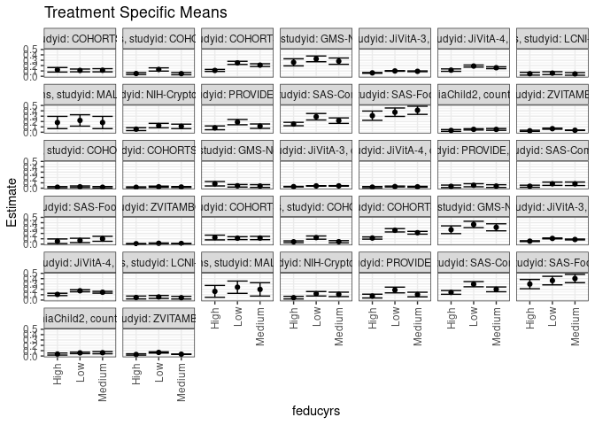

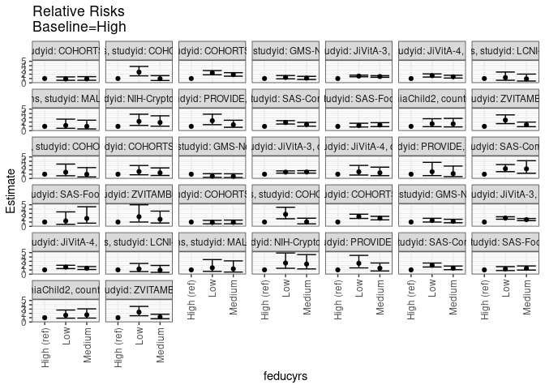

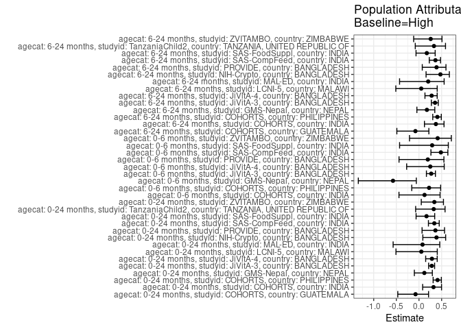

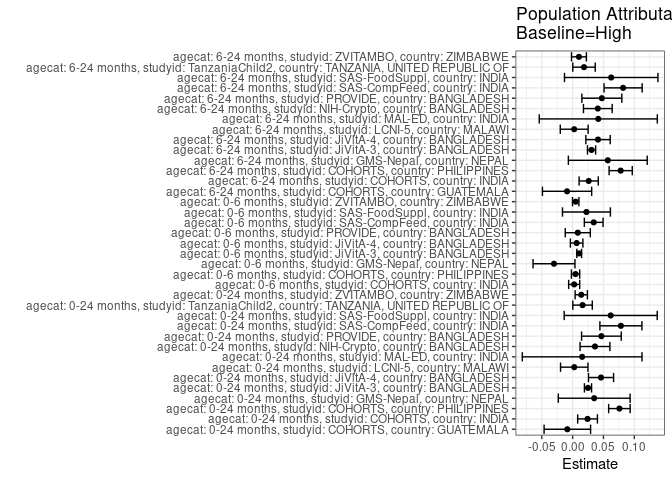

## Results Table

### Parameter: TSM

| agecat | studyid | country | intervention_level | baseline_level | estimate | ci_lower | ci_upper |
| --- | --- | --- | --- | --- | --- | --- | --- |
| 0-24 months | COHORTS | GUATEMALA | High | NA | 0.1212121 | 0.0791072 | 0.1633171 |
| 0-24 months | COHORTS | GUATEMALA | Low | NA | 0.1093190 | 0.0834180 | 0.1352200 |
| 0-24 months | COHORTS | GUATEMALA | Medium | NA | 0.1123596 | 0.0830055 | 0.1417136 |
| 0-24 months | COHORTS | INDIA | High | NA | 0.0511464 | 0.0330074 | 0.0692854 |
| 0-24 months | COHORTS | INDIA | Low | NA | 0.1271186 | 0.0970572 | 0.1571801 |
| 0-24 months | COHORTS | INDIA | Medium | NA | 0.0490196 | 0.0280621 | 0.0699771 |
| 0-24 months | COHORTS | PHILIPPINES | High | NA | 0.1089494 | 0.0898996 | 0.1279992 |
| 0-24 months | COHORTS | PHILIPPINES | Low | NA | 0.2506053 | 0.2210467 | 0.2801640 |
| 0-24 months | COHORTS | PHILIPPINES | Medium | NA | 0.2080868 | 0.1830968 | 0.2330768 |
| 0-24 months | GMS-Nepal | NEPAL | High | NA | 0.2603550 | 0.1941460 | 0.3265640 |
| 0-24 months | GMS-Nepal | NEPAL | Low | NA | 0.3253425 | 0.2715667 | 0.3791182 |
| 0-24 months | GMS-Nepal | NEPAL | Medium | NA | 0.2825112 | 0.2233770 | 0.3416454 |
| 0-24 months | JiVitA-3 | BANGLADESH | High | NA | 0.0633302 | 0.0565773 | 0.0700832 |
| 0-24 months | JiVitA-3 | BANGLADESH | Low | NA | 0.0996609 | 0.0938078 | 0.1055140 |
| 0-24 months | JiVitA-3 | BANGLADESH | Medium | NA | 0.0927788 | 0.0858731 | 0.0996846 |
| 0-24 months | JiVitA-4 | BANGLADESH | High | NA | 0.1146752 | 0.0920436 | 0.1373068 |
| 0-24 months | JiVitA-4 | BANGLADESH | Low | NA | 0.1909882 | 0.1717172 | 0.2102592 |
| 0-24 months | JiVitA-4 | BANGLADESH | Medium | NA | 0.1599229 | 0.1424323 | 0.1774135 |
| 0-24 months | LCNI-5 | MALAWI | High | NA | 0.0478088 | 0.0213972 | 0.0742203 |
| 0-24 months | LCNI-5 | MALAWI | Low | NA | 0.0584192 | 0.0314558 | 0.0853827 |
| 0-24 months | LCNI-5 | MALAWI | Medium | NA | 0.0442804 | 0.0197728 | 0.0687881 |
| 0-24 months | MAL-ED | INDIA | High | NA | 0.1818182 | 0.0674652 | 0.2961712 |
| 0-24 months | MAL-ED | INDIA | Low | NA | 0.2203390 | 0.1142176 | 0.3264604 |
| 0-24 months | MAL-ED | INDIA | Medium | NA | 0.1818182 | 0.0674652 | 0.2961712 |
| 0-24 months | NIH-Crypto | BANGLADESH | High | NA | 0.0574324 | 0.0309094 | 0.0839555 |
| 0-24 months | NIH-Crypto | BANGLADESH | Low | NA | 0.1239669 | 0.0824199 | 0.1655140 |
| 0-24 months | NIH-Crypto | BANGLADESH | Medium | NA | 0.1090909 | 0.0678684 | 0.1503134 |
| 0-24 months | PROVIDE | BANGLADESH | High | NA | 0.0818966 | 0.0465869 | 0.1172062 |
| 0-24 months | PROVIDE | BANGLADESH | Low | NA | 0.1890756 | 0.1392930 | 0.2388583 |
| 0-24 months | PROVIDE | BANGLADESH | Medium | NA | 0.1130435 | 0.0720921 | 0.1539949 |

[output cut: 81 more lines]

### Parameter: E(Y)

| agecat | studyid | country | intervention_level | baseline_level | estimate | ci_lower | ci_upper |
| --- | --- | --- | --- | --- | --- | --- | --- |
| 0-24 months | COHORTS | GUATEMALA | NA | NA | 0.1126418 | 0.0949950 | 0.1302886 |
| 0-24 months | COHORTS | INDIA | NA | NA | 0.0753283 | 0.0617252 | 0.0889313 |
| 0-24 months | COHORTS | PHILIPPINES | NA | NA | 0.1847978 | 0.1705903 | 0.1990052 |
| 0-24 months | GMS-Nepal | NEPAL | NA | NA | 0.2953216 | 0.2611095 | 0.3295338 |
| 0-24 months | JiVitA-3 | BANGLADESH | NA | NA | 0.0882455 | 0.0842753 | 0.0922157 |
| 0-24 months | JiVitA-4 | BANGLADESH | NA | NA | 0.1607278 | 0.1492347 | 0.1722209 |
| 0-24 months | LCNI-5 | MALAWI | NA | NA | 0.0504305 | 0.0353790 | 0.0654820 |
| 0-24 months | MAL-ED | INDIA | NA | NA | 0.1972789 | 0.1327292 | 0.2618286 |
| 0-24 months | NIH-Crypto | BANGLADESH | NA | NA | 0.0936675 | 0.0729118 | 0.1144233 |
| 0-24 months | PROVIDE | BANGLADESH | NA | NA | 0.1285714 | 0.1037574 | 0.1533855 |
| 0-24 months | SAS-CompFeed | INDIA | NA | NA | 0.2311258 | 0.1911027 | 0.2711489 |
| 0-24 months | SAS-FoodSuppl | INDIA | NA | NA | 0.3708134 | 0.3244530 | 0.4171738 |
| 0-24 months | TanzaniaChild2 | TANZANIA, UNITED REPUBLIC OF | NA | NA | 0.0495174 | 0.0408052 | 0.0582296 |
| 0-24 months | ZVITAMBO | ZIMBABWE | NA | NA | 0.0412120 | 0.0378667 | 0.0445574 |
| 0-6 months | COHORTS | INDIA | NA | NA | 0.0204658 | 0.0130911 | 0.0278404 |
| 0-6 months | COHORTS | PHILIPPINES | NA | NA | 0.0212766 | 0.0159935 | 0.0265597 |
| 0-6 months | GMS-Nepal | NEPAL | NA | NA | 0.0526316 | 0.0358852 | 0.0693779 |
| 0-6 months | JiVitA-3 | BANGLADESH | NA | NA | 0.0393561 | 0.0368043 | 0.0419078 |
| 0-6 months | JiVitA-4 | BANGLADESH | NA | NA | 0.0260870 | 0.0207411 | 0.0314328 |
| 0-6 months | PROVIDE | BANGLADESH | NA | NA | 0.0428571 | 0.0278427 | 0.0578716 |
| 0-6 months | SAS-CompFeed | INDIA | NA | NA | 0.0706196 | 0.0480792 | 0.0931600 |
| 0-6 months | SAS-FoodSuppl | INDIA | NA | NA | 0.0769231 | 0.0512858 | 0.1025603 |
| 0-6 months | ZVITAMBO | ZIMBABWE | NA | NA | 0.0121001 | 0.0102537 | 0.0139464 |
| 6-24 months | COHORTS | GUATEMALA | NA | NA | 0.1147687 | 0.0961264 | 0.1334109 |
| 6-24 months | COHORTS | INDIA | NA | NA | 0.0697509 | 0.0564268 | 0.0830750 |
| 6-24 months | COHORTS | PHILIPPINES | NA | NA | 0.1917860 | 0.1768046 | 0.2067673 |
| 6-24 months | GMS-Nepal | NEPAL | NA | NA | 0.3259762 | 0.2880892 | 0.3638632 |
| 6-24 months | JiVitA-3 | BANGLADESH | NA | NA | 0.0864979 | 0.0817318 | 0.0912639 |
| 6-24 months | JiVitA-4 | BANGLADESH | NA | NA | 0.1471927 | 0.1364565 | 0.1579289 |
| 6-24 months | LCNI-5 | MALAWI | NA | NA | 0.0511222 | 0.0358697 | 0.0663747 |
| 6-24 months | MAL-ED | INDIA | NA | NA | 0.2043796 | 0.1366076 | 0.2721516 |
| 6-24 months | NIH-Crypto | BANGLADESH | NA | NA | 0.0863014 | 0.0659171 | 0.1066856 |
| 6-24 months | PROVIDE | BANGLADESH | NA | NA | 0.1221498 | 0.0962275 | 0.1480722 |
| 6-24 months | SAS-CompFeed | INDIA | NA | NA | 0.2251082 | 0.1905625 | 0.2596539 |
| 6-24 months | SAS-FoodSuppl | INDIA | NA | NA | 0.3615960 | 0.3145115 | 0.4086805 |
| 6-24 months | TanzaniaChild2 | TANZANIA, UNITED REPUBLIC OF | NA | NA | 0.0557769 | 0.0457368 | 0.0658170 |
| 6-24 months | ZVITAMBO | ZIMBABWE | NA | NA | 0.0395163 | 0.0357901 | 0.0432425 |

### Parameter: RR

| agecat | studyid | country | intervention_level | baseline_level | estimate | ci_lower | ci_upper |
| --- | --- | --- | --- | --- | --- | --- | --- |
| 0-24 months | COHORTS | GUATEMALA | High | High | 1.0000000 | 1.0000000 | 1.000000 |
| 0-24 months | COHORTS | GUATEMALA | Low | High | 0.9018817 | 0.5922973 | 1.373281 |
| 0-24 months | COHORTS | GUATEMALA | Medium | High | 0.9269663 | 0.6002064 | 1.431618 |
| 0-24 months | COHORTS | INDIA | High | High | 1.0000000 | 1.0000000 | 1.000000 |
| 0-24 months | COHORTS | INDIA | Low | High | 2.4853887 | 1.6228209 | 3.806432 |
| 0-24 months | COHORTS | INDIA | Medium | High | 0.9584178 | 0.5499362 | 1.670312 |
| 0-24 months | COHORTS | PHILIPPINES | High | High | 1.0000000 | 1.0000000 | 1.000000 |
| 0-24 months | COHORTS | PHILIPPINES | Low | High | 2.3001989 | 1.8628025 | 2.840298 |
| 0-24 months | COHORTS | PHILIPPINES | Medium | High | 1.9099394 | 1.5448873 | 2.361252 |
| 0-24 months | GMS-Nepal | NEPAL | High | High | 1.0000000 | 1.0000000 | 1.000000 |
| 0-24 months | GMS-Nepal | NEPAL | Low | High | 1.2496108 | 0.9226851 | 1.692373 |
| 0-24 months | GMS-Nepal | NEPAL | Medium | High | 1.0850999 | 0.7805973 | 1.508386 |
| 0-24 months | JiVitA-3 | BANGLADESH | High | High | 1.0000000 | 1.0000000 | 1.000000 |
| 0-24 months | JiVitA-3 | BANGLADESH | Low | High | 1.5736697 | 1.3989579 | 1.770201 |
| 0-24 months | JiVitA-3 | BANGLADESH | Medium | High | 1.4650006 | 1.2919314 | 1.661254 |
| 0-24 months | JiVitA-4 | BANGLADESH | High | High | 1.0000000 | 1.0000000 | 1.000000 |
| 0-24 months | JiVitA-4 | BANGLADESH | Low | High | 1.6654707 | 1.3337999 | 2.079617 |
| 0-24 months | JiVitA-4 | BANGLADESH | Medium | High | 1.3945727 | 1.1092829 | 1.753234 |
| 0-24 months | LCNI-5 | MALAWI | High | High | 1.0000000 | 1.0000000 | 1.000000 |
| 0-24 months | LCNI-5 | MALAWI | Low | High | 1.2219359 | 0.5948537 | 2.510075 |
| 0-24 months | LCNI-5 | MALAWI | Medium | High | 0.9261993 | 0.4237293 | 2.024512 |
| 0-24 months | MAL-ED | INDIA | High | High | 1.0000000 | 1.0000000 | 1.000000 |
| 0-24 months | MAL-ED | INDIA | Low | High | 1.2118644 | 0.5488063 | 2.676017 |
| 0-24 months | MAL-ED | INDIA | Medium | High | 1.0000000 | 0.4108786 | 2.433809 |
| 0-24 months | NIH-Crypto | BANGLADESH | High | High | 1.0000000 | 1.0000000 | 1.000000 |
| 0-24 months | NIH-Crypto | BANGLADESH | Low | High | 2.1584832 | 1.2199340 | 3.819100 |
| 0-24 months | NIH-Crypto | BANGLADESH | Medium | High | 1.8994652 | 1.0458867 | 3.449674 |
| 0-24 months | PROVIDE | BANGLADESH | High | High | 1.0000000 | 1.0000000 | 1.000000 |
| 0-24 months | PROVIDE | BANGLADESH | Low | High | 2.3087130 | 1.3930608 | 3.826219 |
| 0-24 months | PROVIDE | BANGLADESH | Medium | High | 1.3803204 | 0.7859819 | 2.424082 |

[output cut: 81 more lines]

### Parameter: PAR

| agecat | studyid | country | intervention_level | baseline_level | estimate | ci_lower | ci_upper |
| --- | --- | --- | --- | --- | --- | --- | --- |
| 0-24 months | COHORTS | GUATEMALA | High | NA | -0.0085703 | -0.0462599 | 0.0291193 |
| 0-24 months | COHORTS | INDIA | High | NA | 0.0241819 | 0.0081752 | 0.0401886 |
| 0-24 months | COHORTS | PHILIPPINES | High | NA | 0.0758484 | 0.0583957 | 0.0933010 |
| 0-24 months | GMS-Nepal | NEPAL | High | NA | 0.0349666 | -0.0232393 | 0.0931725 |
| 0-24 months | JiVitA-3 | BANGLADESH | High | NA | 0.0249153 | 0.0191146 | 0.0307159 |
| 0-24 months | JiVitA-4 | BANGLADESH | High | NA | 0.0460526 | 0.0257116 | 0.0663936 |
| 0-24 months | LCNI-5 | MALAWI | High | NA | 0.0026217 | -0.0195907 | 0.0248342 |
| 0-24 months | MAL-ED | INDIA | High | NA | 0.0154607 | -0.0815707 | 0.1124922 |
| 0-24 months | NIH-Crypto | BANGLADESH | High | NA | 0.0362351 | 0.0120512 | 0.0604190 |
| 0-24 months | PROVIDE | BANGLADESH | High | NA | 0.0466749 | 0.0144867 | 0.0788630 |
| 0-24 months | SAS-CompFeed | INDIA | High | NA | 0.0782761 | 0.0442189 | 0.1123333 |
| 0-24 months | SAS-FoodSuppl | INDIA | High | NA | 0.0617225 | -0.0137123 | 0.1371572 |
| 0-24 months | TanzaniaChild2 | TANZANIA, UNITED REPUBLIC OF | High | NA | 0.0161098 | 0.0003574 | 0.0318622 |
| 0-24 months | ZVITAMBO | ZIMBABWE | High | NA | 0.0139943 | 0.0040579 | 0.0239306 |
| 0-6 months | COHORTS | INDIA | High | NA | 0.0025125 | -0.0064544 | 0.0114793 |
| 0-6 months | COHORTS | PHILIPPINES | High | NA | 0.0047396 | -0.0019767 | 0.0114559 |
| 0-6 months | GMS-Nepal | NEPAL | High | NA | -0.0302087 | -0.0641987 | 0.0037814 |
| 0-6 months | JiVitA-3 | BANGLADESH | High | NA | 0.0106472 | 0.0067435 | 0.0145508 |
| 0-6 months | JiVitA-4 | BANGLADESH | High | NA | 0.0065125 | -0.0036382 | 0.0166631 |
| 0-6 months | PROVIDE | BANGLADESH | High | NA | 0.0083744 | -0.0119125 | 0.0286613 |
| 0-6 months | SAS-CompFeed | INDIA | High | NA | 0.0341613 | 0.0189755 | 0.0493470 |
| 0-6 months | SAS-FoodSuppl | INDIA | High | NA | 0.0223776 | -0.0164533 | 0.0612085 |
| 0-6 months | ZVITAMBO | ZIMBABWE | High | NA | 0.0049935 | -0.0001935 | 0.0101805 |
| 6-24 months | COHORTS | GUATEMALA | High | NA | -0.0090408 | -0.0489349 | 0.0308533 |
| 6-24 months | COHORTS | INDIA | High | NA | 0.0260350 | 0.0104950 | 0.0415751 |
| 6-24 months | COHORTS | PHILIPPINES | High | NA | 0.0779031 | 0.0591199 | 0.0966864 |
| 6-24 months | GMS-Nepal | NEPAL | High | NA | 0.0570107 | -0.0068976 | 0.1209190 |
| 6-24 months | JiVitA-3 | BANGLADESH | High | NA | 0.0306765 | 0.0240329 | 0.0373202 |
| 6-24 months | JiVitA-4 | BANGLADESH | High | NA | 0.0411686 | 0.0214286 | 0.0609086 |
| 6-24 months | LCNI-5 | MALAWI | High | NA | 0.0025392 | -0.0200232 | 0.0251016 |
| 6-24 months | MAL-ED | INDIA | High | NA | 0.0415889 | -0.0541133 | 0.1372910 |
| 6-24 months | NIH-Crypto | BANGLADESH | High | NA | 0.0408468 | 0.0175697 | 0.0641240 |
| 6-24 months | PROVIDE | BANGLADESH | High | NA | 0.0473835 | 0.0149990 | 0.0797679 |
| 6-24 months | SAS-CompFeed | INDIA | High | NA | 0.0818650 | 0.0509938 | 0.1127361 |
| 6-24 months | SAS-FoodSuppl | INDIA | High | NA | 0.0625306 | -0.0132011 | 0.1382623 |
| 6-24 months | TanzaniaChild2 | TANZANIA, UNITED REPUBLIC OF | High | NA | 0.0184436 | 0.0002345 | 0.0366526 |
| 6-24 months | ZVITAMBO | ZIMBABWE | High | NA | 0.0102276 | -0.0018315 | 0.0222867 |

### Parameter: PAF

| agecat | studyid | country | intervention_level | baseline_level | estimate | ci_lower | ci_upper |
| --- | --- | --- | --- | --- | --- | --- | --- |
| 0-24 months | COHORTS | GUATEMALA | High | NA | -0.0760846 | -0.4683284 | 0.2113767 |
| 0-24 months | COHORTS | INDIA | High | NA | 0.3210200 | 0.0812492 | 0.4982167 |
| 0-24 months | COHORTS | PHILIPPINES | High | NA | 0.4104398 | 0.3126277 | 0.4943333 |
| 0-24 months | GMS-Nepal | NEPAL | High | NA | 0.1184018 | -0.1023048 | 0.2949179 |
| 0-24 months | JiVitA-3 | BANGLADESH | High | NA | 0.2823402 | 0.2133085 | 0.3453145 |
| 0-24 months | JiVitA-4 | BANGLADESH | High | NA | 0.2865254 | 0.1478323 | 0.4026457 |
| 0-24 months | LCNI-5 | MALAWI | High | NA | 0.0519872 | -0.5082706 | 0.4041332 |
| 0-24 months | MAL-ED | INDIA | High | NA | 0.0783699 | -0.5709251 | 0.4592982 |
| 0-24 months | NIH-Crypto | BANGLADESH | High | NA | 0.3868481 | 0.0850065 | 0.5891170 |
| 0-24 months | PROVIDE | BANGLADESH | High | NA | 0.3630268 | 0.0682562 | 0.5645425 |
| 0-24 months | SAS-CompFeed | INDIA | High | NA | 0.3386730 | 0.2088344 | 0.4472038 |
| 0-24 months | SAS-FoodSuppl | INDIA | High | NA | 0.1664516 | -0.0639281 | 0.3469456 |
| 0-24 months | TanzaniaChild2 | TANZANIA, UNITED REPUBLIC OF | High | NA | 0.3253369 | -0.0733980 | 0.5759538 |
| 0-24 months | ZVITAMBO | ZIMBABWE | High | NA | 0.3395681 | 0.0507181 | 0.5405260 |
| 0-6 months | COHORTS | INDIA | High | NA | 0.1227636 | -0.4419798 | 0.4663283 |
| 0-6 months | COHORTS | PHILIPPINES | High | NA | 0.2227626 | -0.1595821 | 0.4790383 |
| 0-6 months | GMS-Nepal | NEPAL | High | NA | -0.5739645 | -1.3399725 | -0.0587151 |
| 0-6 months | JiVitA-3 | BANGLADESH | High | NA | 0.2705348 | 0.1643035 | 0.3632624 |
| 0-6 months | JiVitA-4 | BANGLADESH | High | NA | 0.2496454 | -0.2723716 | 0.5574940 |
| 0-6 months | PROVIDE | BANGLADESH | High | NA | 0.1954023 | -0.4407600 | 0.5506695 |
| 0-6 months | SAS-CompFeed | INDIA | High | NA | 0.4837362 | 0.2640471 | 0.6378460 |
| 0-6 months | SAS-FoodSuppl | INDIA | High | NA | 0.2909091 | -0.4282555 | 0.6479552 |
| 0-6 months | ZVITAMBO | ZIMBABWE | High | NA | 0.4126810 | -0.2091213 | 0.7147155 |
| 6-24 months | COHORTS | GUATEMALA | High | NA | -0.0787745 | -0.4886801 | 0.2182644 |
| 6-24 months | COHORTS | INDIA | High | NA | 0.3732575 | 0.1207049 | 0.5532715 |
| 6-24 months | COHORTS | PHILIPPINES | High | NA | 0.4061982 | 0.3041445 | 0.4932848 |
| 6-24 months | GMS-Nepal | NEPAL | High | NA | 0.1748922 | -0.0461413 | 0.3492248 |
| 6-24 months | JiVitA-3 | BANGLADESH | High | NA | 0.3546505 | 0.2746162 | 0.4258543 |
| 6-24 months | JiVitA-4 | BANGLADESH | High | NA | 0.2796920 | 0.1320558 | 0.4022154 |
| 6-24 months | LCNI-5 | MALAWI | High | NA | 0.0496692 | -0.5116912 | 0.4025707 |
| 6-24 months | MAL-ED | INDIA | High | NA | 0.2034884 | -0.4286845 | 0.5559336 |
| 6-24 months | NIH-Crypto | BANGLADESH | High | NA | 0.4733045 | 0.1565964 | 0.6710849 |
| 6-24 months | PROVIDE | BANGLADESH | High | NA | 0.3879128 | 0.0726492 | 0.5959989 |
| 6-24 months | SAS-CompFeed | INDIA | High | NA | 0.3636694 | 0.2273165 | 0.4759606 |
| 6-24 months | SAS-FoodSuppl | INDIA | High | NA | 0.1729294 | -0.0653146 | 0.3578932 |
| 6-24 months | TanzaniaChild2 | TANZANIA, UNITED REPUBLIC OF | High | NA | 0.3306667 | -0.0819291 | 0.5859182 |
| 6-24 months | ZVITAMBO | ZIMBABWE | High | NA | 0.2588194 | -0.1173754 | 0.5083580 |